# Expedia Hotel Commendation

Planning your dream vacation, or even a weekend escape, can be an overwhelming affair. With hundreds, even thousands, of hotels to choose from at every destination, it's difficult to know which will suit your personal preferences. Should you go with an old standby with those pillow mints you like, or risk a new hotel with a trendy pool bar?

[figure not shown]

Expedia wants to take the proverbial rabbit hole out of hotel search by providing personalized hotel recommendations to their users. This is no small task for a site with hundreds of millions of visitors every month!

Currently, Expedia uses search parameters to adjust their hotel recommendations, but there aren't enough customer specific data to personalize them for each user. In this competition, Expedia is challenging Kagglers to contextualize customer data and predict the likelihood a user will stay at 100 different hotel groups.

**The data in this competition is a random selection from Expedia and is not representative of the overall statistics.**

# 1. Understand the problem:

Expedia wants to provide personalized hotel recommendations to their users by predicting the likelihood a user will stay at 100 different hotel groups based on contextualized customer data.

# 2.Analyze the dataset:

Explore the provided datasets (train.csv, test.csv, destinations.csv) to understand the features, data types, and any missing values.

```python
#import libraries
import pandas as pd
import numpy as np
import random
```

```python
#Load datasets
train_data=pd.read_csv('train.csv')
test_data=pd.read_csv('test.csv')
destinations_data=pd.read_csv('destinations.csv')
```

```python
train_data.head(5)
```

|  | date_time | site_name | posa_continent | user_location_country | user_location_region | user_location_city | orig_destination_distance | user_id | is_mobile | is_package | ... | srch_children_cnt | srch_rm_cnt | srch_destination_id | srch_destination_type_id | is_booking | cnt | hotel_continent | hotel_country | hotel_market | hotel_cluster |
| --- | --- | --- | --- | --- | --- | --- | --- | --- | --- | --- | --- | --- | --- | --- | --- | --- | --- | --- | --- | --- | --- |
| 0 | 2014-08-11 07:46:59 | 2 | 3 | 66 | 348 | 48862 | 2234.2641 | 12 | 0 | 1 | ... | 0 | 1 | 8250 | 1 | 0 | 3 | 2 | 50 | 628 | 1 |
| 1 | 2014-08-11 08:22:12 | 2 | 3 | 66 | 348 | 48862 | 2234.2641 | 12 | 0 | 1 | ... | 0 | 1 | 8250 | 1 | 1 | 1 | 2 | 50 | 628 | 1 |
| 2 | 2014-08-11 08:24:33 | 2 | 3 | 66 | 348 | 48862 | 2234.2641 | 12 | 0 | 0 | ... | 0 | 1 | 8250 | 1 | 0 | 1 | 2 | 50 | 628 | 1 |
| 3 | 2014-08-09 18:05:16 | 2 | 3 | 66 | 442 | 35390 | 913.1932 | 93 | 0 | 0 | ... | 0 | 1 | 14984 | 1 | 0 | 1 | 2 | 50 | 1457 | 80 |
| 4 | 2014-08-09 18:08:18 | 2 | 3 | 66 | 442 | 35390 | 913.6259 | 93 | 0 | 0 | ... | 0 | 1 | 14984 | 1 | 0 | 1 | 2 | 50 | 1457 | 21 |

5 rows × 24 columns

```python
test_data.head(5)
```

|  | id | date_time | site_name | posa_continent | user_location_country | user_location_region | user_location_city | orig_destination_distance | user_id | is_mobile | ... | srch_ci | srch_co | srch_adults_cnt | srch_children_cnt | srch_rm_cnt | srch_destination_id | srch_destination_type_id | hotel_continent | hotel_country | hotel_market |
| --- | --- | --- | --- | --- | --- | --- | --- | --- | --- | --- | --- | --- | --- | --- | --- | --- | --- | --- | --- | --- | --- |
| 0 | 0 | 2015-09-03 17:09:54 | 2 | 3 | 66 | 174 | 37449 | 5539.0567 | 1 | 1 | ... | 2016-05-19 | 2016-05-23 | 2 | 0 | 1 | 12243 | 6 | 6 | 204 | 27 |
| 1 | 1 | 2015-09-24 17:38:35 | 2 | 3 | 66 | 174 | 37449 | 5873.2923 | 1 | 1 | ... | 2016-05-12 | 2016-05-15 | 2 | 0 | 1 | 14474 | 7 | 6 | 204 | 1540 |
| 2 | 2 | 2015-06-07 15:53:02 | 2 | 3 | 66 | 142 | 17440 | 3975.9776 | 20 | 0 | ... | 2015-07-26 | 2015-07-27 | 4 | 0 | 1 | 11353 | 1 | 2 | 50 | 699 |
| 3 | 3 | 2015-09-14 14:49:10 | 2 | 3 | 66 | 258 | 34156 | 1508.5975 | 28 | 0 | ... | 2015-09-14 | 2015-09-16 | 2 | 0 | 1 | 8250 | 1 | 2 | 50 | 628 |
| 4 | 4 | 2015-07-17 09:32:04 | 2 | 3 | 66 | 467 | 36345 | 66.7913 | 50 | 0 | ... | 2015-07-22 | 2015-07-23 | 2 | 0 | 1 | 11812 | 1 | 2 | 50 | 538 |

5 rows × 22 columns

```python
destinations_data.head(5)
```

|  | srch_destination_id | d1 | d2 | d3 | d4 | d5 | d6 | d7 | d8 | d9 | ... | d140 | d141 | d142 | d143 | d144 | d145 | d146 | d147 | d148 | d149 |
| --- | --- | --- | --- | --- | --- | --- | --- | --- | --- | --- | --- | --- | --- | --- | --- | --- | --- | --- | --- | --- | --- |
| 0 | 0 | -2.198657 | -2.198657 | -2.198657 | -2.198657 | -2.198657 | -1.897627 | -2.198657 | -2.198657 | -1.897627 | ... | -2.198657 | -2.198657 | -2.198657 | -2.198657 | -2.198657 | -2.198657 | -2.198657 | -2.198657 | -2.198657 | -2.198657 |
| 1 | 1 | -2.181690 | -2.181690 | -2.181690 | -2.082564 | -2.181690 | -2.165028 | -2.181690 | -2.181690 | -2.031597 | ... | -2.165028 | -2.181690 | -2.165028 | -2.181690 | -2.181690 | -2.165028 | -2.181690 | -2.181690 | -2.181690 | -2.181690 |
| 2 | 2 | -2.183490 | -2.224164 | -2.224164 | -2.189562 | -2.105819 | -2.075407 | -2.224164 | -2.118483 | -2.140393 | ... | -2.224164 | -2.224164 | -2.196379 | -2.224164 | -2.192009 | -2.224164 | -2.224164 | -2.224164 | -2.224164 | -2.057548 |
| 3 | 3 | -2.177409 | -2.177409 | -2.177409 | -2.177409 | -2.177409 | -2.115485 | -2.177409 | -2.177409 | -2.177409 | ... | -2.161081 | -2.177409 | -2.177409 | -2.177409 | -2.177409 | -2.177409 | -2.177409 | -2.177409 | -2.177409 | -2.177409 |
| 4 | 4 | -2.189562 | -2.187783 | -2.194008 | -2.171153 | -2.152303 | -2.056618 | -2.194008 | -2.194008 | -2.145911 | ... | -2.187356 | -2.194008 | -2.191779 | -2.194008 | -2.194008 | -2.185161 | -2.194008 | -2.194008 | -2.194008 | -2.188037 |

5 rows × 150 columns

```python
# Analysis Data set
train_data.describe()
```

|  | site_name | posa_continent | user_location_country | user_location_region | user_location_city | orig_destination_distance | user_id | is_mobile | is_package | channel | ... | srch_children_cnt | srch_rm_cnt | srch_destination_id | srch_destination_type_id | is_booking | cnt | hotel_continent | hotel_country | hotel_market | hotel_cluster |
| --- | --- | --- | --- | --- | --- | --- | --- | --- | --- | --- | --- | --- | --- | --- | --- | --- | --- | --- | --- | --- | --- |
| count | 3.767029e+07 | 3.767029e+07 | 3.767029e+07 | 3.767029e+07 | 3.767029e+07 | 2.414529e+07 | 3.767029e+07 | 3.767029e+07 | 3.767029e+07 | 3.767029e+07 | ... | 3.767029e+07 | 3.767029e+07 | 3.767029e+07 | 3.767029e+07 | 3.767029e+07 | 3.767029e+07 | 3.767029e+07 | 3.767029e+07 | 3.767029e+07 | 3.767029e+07 |
| mean | 9.795271e+00 | 2.680473e+00 | 8.610880e+01 | 3.084060e+02 | 2.775304e+04 | 1.970090e+03 | 6.044518e+05 | 1.349265e-01 | 2.489042e-01 | 5.870761e+00 | ... | 3.321222e-01 | 1.112663e+00 | 1.444109e+04 | 2.582280e+00 | 7.965675e-02 | 1.483384e+00 | 3.156305e+00 | 8.129685e+01 | 6.004619e+02 | 4.980861e+01 |
| std | 1.196754e+01 | 7.480393e-01 | 5.924310e+01 | 2.084437e+02 | 1.678255e+04 | 2.232442e+03 | 3.506175e+05 | 3.416451e-01 | 4.323782e-01 | 3.717095e+00 | ... | 7.314981e-01 | 4.591155e-01 | 1.106630e+04 | 2.153019e+00 | 2.707611e-01 | 1.219776e+00 | 1.623189e+00 | 5.617119e+01 | 5.117391e+02 | 2.891595e+01 |
| min | 2.000000e+00 | 0.000000e+00 | 0.000000e+00 | 0.000000e+00 | 0.000000e+00 | 5.600000e-03 | 0.000000e+00 | 0.000000e+00 | 0.000000e+00 | 0.000000e+00 | ... | 0.000000e+00 | 0.000000e+00 | 0.000000e+00 | 0.000000e+00 | 0.000000e+00 | 1.000000e+00 | 0.000000e+00 | 0.000000e+00 | 0.000000e+00 | 0.000000e+00 |
| 25% | 2.000000e+00 | 3.000000e+00 | 6.600000e+01 | 1.740000e+02 | 1.300900e+04 | 3.131670e+02 | 2.989100e+05 | 0.000000e+00 | 0.000000e+00 | 2.000000e+00 | ... | 0.000000e+00 | 1.000000e+00 | 8.267000e+03 | 1.000000e+00 | 0.000000e+00 | 1.000000e+00 | 2.000000e+00 | 5.000000e+01 | 1.600000e+02 | 2.500000e+01 |
| 50% | 2.000000e+00 | 3.000000e+00 | 6.600000e+01 | 3.140000e+02 | 2.765500e+04 | 1.140491e+03 | 6.039140e+05 | 0.000000e+00 | 0.000000e+00 | 9.000000e+00 | ... | 0.000000e+00 | 1.000000e+00 | 9.147000e+03 | 1.000000e+00 | 0.000000e+00 | 1.000000e+00 | 2.000000e+00 | 5.000000e+01 | 5.930000e+02 | 4.900000e+01 |
| 75% | 1.400000e+01 | 3.000000e+00 | 7.000000e+01 | 3.850000e+02 | 4.241300e+04 | 2.552599e+03 | 9.101680e+05 | 0.000000e+00 | 0.000000e+00 | 9.000000e+00 | ... | 0.000000e+00 | 1.000000e+00 | 1.879000e+04 | 5.000000e+00 | 0.000000e+00 | 2.000000e+00 | 4.000000e+00 | 1.060000e+02 | 7.010000e+02 | 7.300000e+01 |
| max | 5.300000e+01 | 4.000000e+00 | 2.390000e+02 | 1.027000e+03 | 5.650800e+04 | 1.240790e+04 | 1.198785e+06 | 1.000000e+00 | 1.000000e+00 | 1.000000e+01 | ... | 9.000000e+00 | 8.000000e+00 | 6.510700e+04 | 9.000000e+00 | 1.000000e+00 | 2.690000e+02 | 6.000000e+00 | 2.120000e+02 | 2.117000e+03 | 9.900000e+01 |

8 rows × 21 columns

```python
#Checking missing value
#print(train_data.isnull().sum())
```

# 3.Preprocess the data:

Clean and preprocess the data, handle missing values, and perform any necessary feature engineering to extract meaningful information from the dataset.

```python
#drop useless columns
train_data=train_data.drop(['site_name','orig_destination_distance'],axis=1)
#test_data=train_data.drop(['date_time','site_name','orig_destination_distance', 'user_id'],axis=1)
```

```python
test_data=test_data.drop(['site_name','orig_destination_distance'],axis=1)
```

```python
#Convert date_time, srch_ci and srch_co to date type
train_data['date_time']=pd.to_datetime(train_data['date_time'])
train_data['srch_ci']=pd.to_datetime(train_data['srch_ci'], errors='coerce')
train_data['srch_co']=pd.to_datetime(train_data['srch_co'], errors='coerce')
```

```python
train_data.dropna(subset=['srch_ci', 'srch_co'], inplace=True)
test_data.dropna(subset=['srch_ci', 'srch_co'], inplace=True)
```

```python
#print(train_data.isnull().sum())
```

```python
# Calculate length of stay and add it as a new feature
train_data['length_of_stay'] = (train_data['srch_co'] - train_data['srch_ci']).dt.days
```

```python
# Remove rows with non-positive 'length_of_stay'
train_data=train_data[train_data['length_of_stay']>=0]
```

```python
 #Fill missing values in 'length_of_stay' with the median value
median_days=train_data['length_of_stay'].median()
```

```python
train_data['length_of_stay'].fillna(median_days,inplace=True)
```

```python
#is_booing should be 1
train_df=train_data[train_data['is_booking']==1].drop('is_booking',axis=1)
```

```python
#To create a heatmap to visualize the correlation between features
import seaborn as sns
import matplotlib.pyplot as plt
```

```python
corr_matrix = train_df.corr()
```

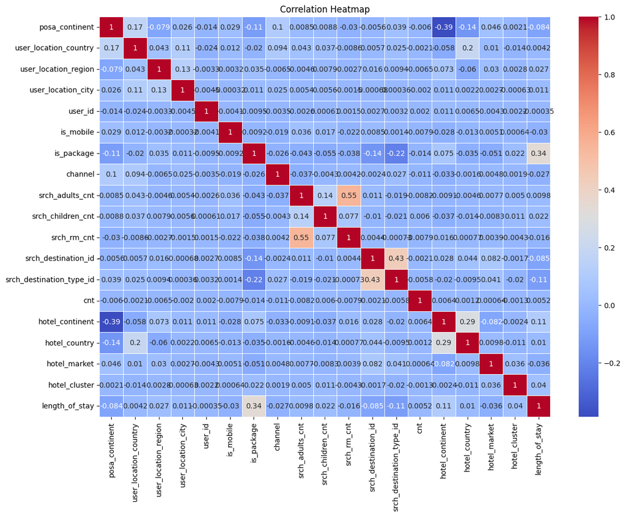

```python
#Create the plot
plt.figure(figsize=(14,10))
sns.heatmap(corr_matrix, annot=True, cmap='coolwarm', linewidths=0.5)
plt.title('Correlation Heatmap')
plt.show()
```

# 4.Split the data:

Split the training data from 2013 and 2014 into training and validation sets to evaluate your model's performance during training.

```python
train_features=[ 'posa_continent', 'user_location_country', 'user_location_region', 'user_location_city',
             'is_mobile', 'is_package', 'channel', 'length_of_stay','user_id',
            'srch_adults_cnt', 'srch_children_cnt', 'srch_rm_cnt', 'srch_destination_id', 'srch_destination_type_id',
            'hotel_continent', 'hotel_country', 'hotel_market', 'cnt']
target_feature=['hotel_cluster']
```

```python
# Select features and target variable
X=train_df[train_features]
y=train_df[target_feature]
```

```python
#Spilit the data into train and validation
from sklearn.model_selection import train_test_split
```

```python
X_train,X_val,y_train,y_val=train_test_split(X,y,test_size=0.3,random_state=22)
```

```python
# Print the shapes of the resulting sets
print("\nX_train shape:", X_train.shape)
print("y_train shape:", y_train.shape)
print("X_val shape:", X_val.shape)
print("y_val shape:", y_val.shape)
```

```
X_train shape: (2100483, 18)
y_train shape: (2100483, 1)
X_val shape: (900207, 18)
y_val shape: (900207, 1)
```

Exploratory Data Analysis (EDA) on the dataset to visualize and discuss key features

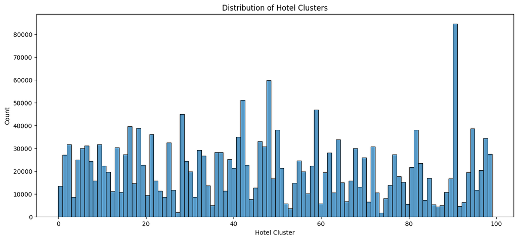

```python
# Feature 1: Distribution of hotel clusters
plt.figure(figsize=(14, 6))
sns.histplot(y_train['hotel_cluster'], bins=100, kde=False)
plt.title('Distribution of Hotel Clusters')
plt.xlabel('Hotel Cluster')
plt.ylabel('Count')
plt.show()
```

```python
#Distribution of booking by month
train_df['Booking_month']=train_df['date_time'].dt.month
booking_by_month=train_df.groupby('Booking_month')['length_of_stay'].count()
```

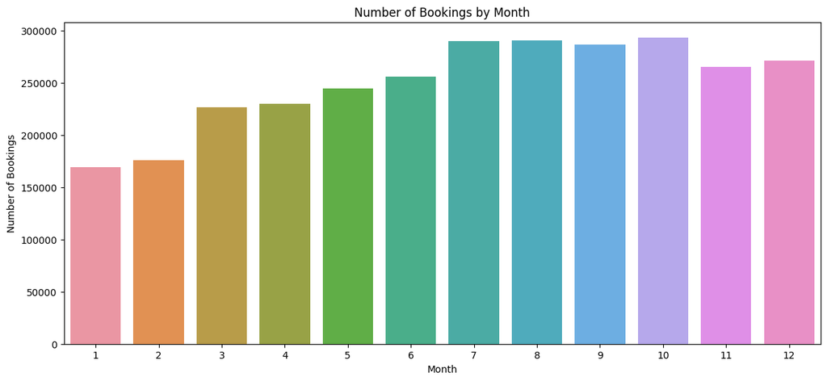

```python
plt.figure(figsize=(14, 6))
sns.barplot(x=booking_by_month.index, y=booking_by_month.values)
plt.title('Number of Bookings by Month')
plt.xlabel('Month')
plt.ylabel('Number of Bookings')
plt.show()
```

```python
# Feature 3: Relationship between user country and hotel country
user_hotel_country=X_train.groupby(['user_location_country', 'hotel_country']).size().reset_index(name='count')
# Filter to keep only those pairs with more than 50 bookings
user_hotel_country=user_hotel_country[user_hotel_country['count']>=50]
```

```python
user_hotel_country.head(3)
```

|  | user_location_country | hotel_country | count |
| --- | --- | --- | --- |
| 5 | 0 | 5 | 128 |
| 18 | 0 | 22 | 71 |
| 28 | 0 | 34 | 81 |

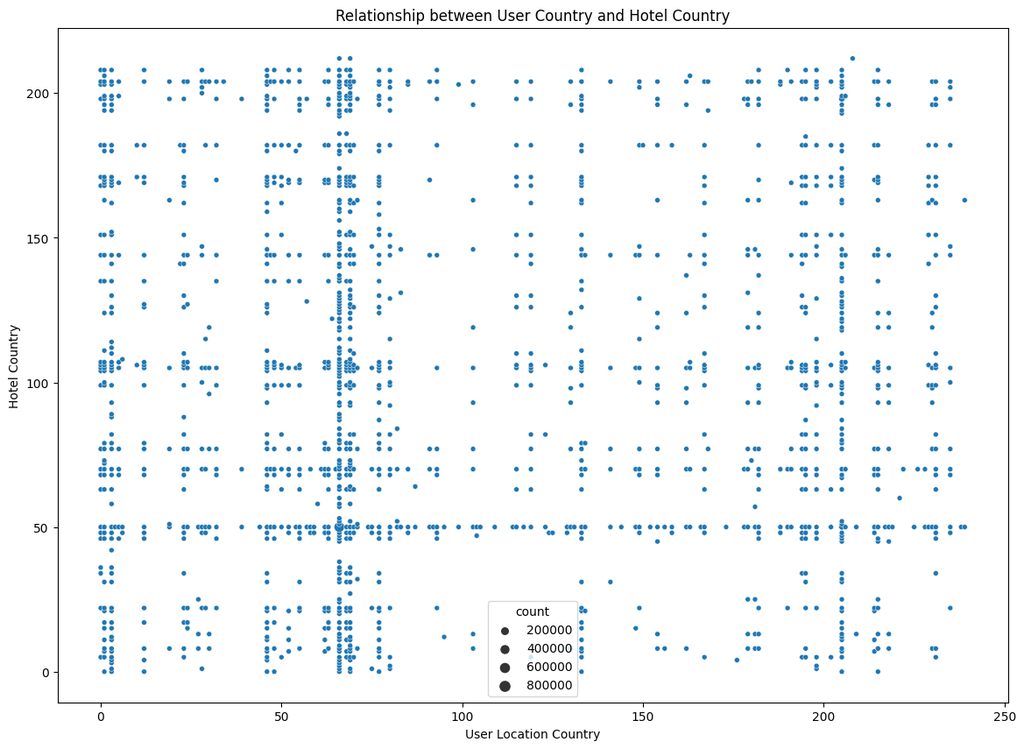

```python
plt.figure(figsize=(14,10))
sns.scatterplot(x='user_location_country',y='hotel_country',size='count',data=user_hotel_country)
plt.title('Relationship between User Country and Hotel Country')
plt.xlabel('User Location Country')
plt.ylabel('Hotel Country')
plt.show()
```

```python
# Feature 4: Relationship between the number of adults and hotel cluster
adults_hotel_cluster=train_df.groupby(['srch_adults_cnt','hotel_cluster']).size().reset_index(name='count')
adults_hotel_cluster.head(3)
```

|  | srch_adults_cnt | hotel_cluster | count |
| --- | --- | --- | --- |
| 0 | 0 | 0 | 90 |
| 1 | 0 | 1 | 150 |
| 2 | 0 | 2 | 115 |

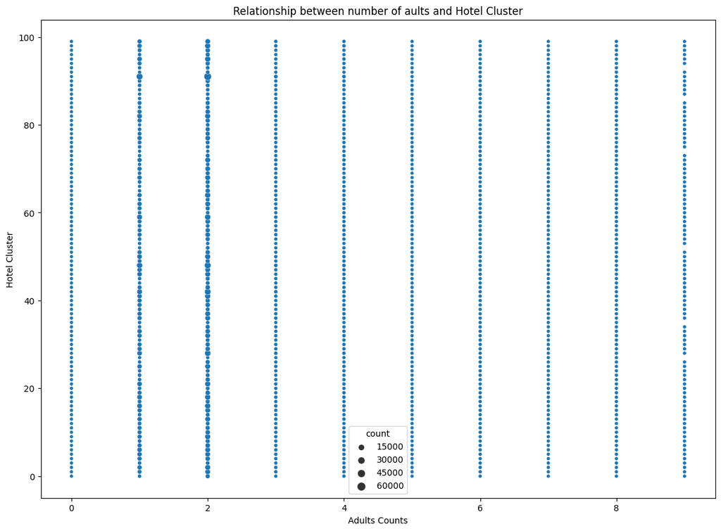

```python
plt.figure(figsize=(14,10))
sns.scatterplot(x='srch_adults_cnt',y='hotel_cluster',size='count',data=adults_hotel_cluster)
plt.title('Relationship between number of aults and Hotel Cluster')
plt.xlabel('Adults Counts')
plt.ylabel('Hotel Cluster')
plt.show()
```

# 5. Choose a model:

Select a suitable machine learning model based on the problem and dataset characteristics.

# 6. Train the model:

Train the chosen model using the training dataset.

# 7. Validate the model:

Evaluate the model's performance on the validation set, and fine-tune the model's hyperparameters if necessary.

Method 1:Logistic Regression model:

```python
X_train.info()
```

```
<class 'pandas.core.frame.DataFrame'>
Int64Index: 2100483 entries, 37213395 to 24396776
Data columns (total 18 columns):
 #   Column                    Dtype
---  ------                    -----
 0   posa_continent            int64
 1   user_location_country     int64
 2   user_location_region      int64
 3   user_location_city        int64
 4   is_mobile                 int64
 5   is_package                int64
 6   channel                   int64
 7   length_of_stay            int64
 8   user_id                   int64
 9   srch_adults_cnt           int64
 10  srch_children_cnt         int64
 11  srch_rm_cnt               int64
 12  srch_destination_id       int64
 13  srch_destination_type_id  int64
 14  hotel_continent           int64
 15  hotel_country             int64
 16  hotel_market              int64
 17  cnt                       int64
dtypes: int64(18)
memory usage: 304.5 MB
```

```python
from sklearn.linear_model import LogisticRegression
from sklearn.metrics import accuracy_score
```

```python
#Lr_model=LogisticRegression(max_iter=1000,random_state=22)
#Lr_model.fit(X_train,y_train)
```

```python
# Make predictions and calculate accuracy
#y_pred = Lr_model.predict(X_val)
#accuracy = accuracy_score(y_val, y_pred)
#print("Logistic Regression Accuracy:", accuracy)
```

Logistic Regression Accuracy: 0.04958415120077938

Random Forest

```python
from sklearn.ensemble import RandomForestClassifier
from sklearn.metrics import accuracy_score
```

```python
# Random Forest Classifier
sample_df = train_df.sample(frac=0.1, random_state=22)
```

```python
X_R=train_df[train_features]
y_R=train_df[target_feature]
```

```python
X_train_r,X_val_r,y_train_r,y_val_r=train_test_split(X_R,y_R,test_size=0.3,random_state=22)
```

```python
rf_clf = RandomForestClassifier(n_estimators=10, random_state=42)
rf_clf.fit(X_train_r, y_train_r)
```

```
RandomForestClassifier(n_estimators=10, random_state=42)
```

```python
# Make predictions and calculate accuracy
y_pred = rf_clf.predict(X_val)
accuracy = accuracy_score(y_val, y_pred)
print("Random Forest Classifier Accuracy:", accuracy)
```

```
Random Forest Classifier Accuracy: 0.17164163353539796
```

Random Forest Classifier Accuracy: 0.17164163353539796

```python
# I will use Sample df to calculate the Pearson Correlation Coefficient
correlations = sample_df.corr()['hotel_cluster'].drop('hotel_cluster').abs()
```

```python
top_5_features_corr = correlations.nlargest(7)
print(top_5_features_corr)
```

```
length_of_stay              0.037689
hotel_market                0.034857
is_package                  0.022052
srch_destination_type_id    0.021479
user_location_country       0.016631
hotel_country               0.012882
srch_children_cnt           0.007676
Name: hotel_cluster, dtype: float64
```

```python
#Recursive Feature Elimination (RFE):
from sklearn.feature_selection import RFE
```

Feature Importance from a Tree-based model:

```python
importances = pd.Series(rf_clf.feature_importances_, index=X.columns)
top_5_features_rf = importances.nlargest(5)
print(top_5_features_rf)
```

```
user_id                 0.227521
user_location_city      0.180328
user_location_region    0.119540
srch_destination_id     0.083869
hotel_market            0.068954
dtype: float64
```

```python
#Create a set of features from both lists:
top_features_corr = set(top_5_features_corr.index)
top_features_rf = set(top_5_features_rf.index)

combined_features = top_features_corr.union(top_features_rf)
print(combined_features)
```

```
{'is_package', 'user_location_city', 'user_id', 'hotel_market', 'length_of_stay', 'user_location_country', 'srch_children_cnt', 'srch_destination_type_id', 'srch_destination_id', 'user_location_region', 'hotel_country'}
```

```python
combined_features=['srch_destination_type_id', 'hotel_market', 'user_location_city', 'srch_destination_id', 'user_location_region', 'user_location_country', 'length_of_stay', 'srch_children_cnt', 'is_package', 'user_id', 'hotel_country']
```

```python
X_new = X_R[list(combined_features)]
```

```python
X_train_2,X_val_2,y_train_2,y_val_2=train_test_split(X_new,y_R,test_size=0.3,random_state=22)
```

```python
rf_clf.fit(X_train_2, y_train_2)
```

```
RandomForestClassifier(n_estimators=10, random_state=42)
```

```python
# Make predictions and calculate accuracy
y_pred = rf_clf.predict(X_val_2)
accuracy = accuracy_score(y_val, y_pred)
print("Random Forest Classifier Accuracy:", accuracy)
```

```
Random Forest Classifier Accuracy: 0.18048626593661235
```

## The model didn't improve significantly, and I needed to try to modify the data to see if I could get better results.

```python
from sklearn.preprocessing import StandardScaler, OneHotEncoder
from sklearn.compose import ColumnTransformer
from sklearn.pipeline import Pipeline
from sklearn.preprocessing import FunctionTransformer
```

```python
#X_new,y_R
numeric_features = X_new.select_dtypes(include=[np.number]).columns
categorical_features = X_new.select_dtypes(include=[np.object]).columns
```

```python
numeric_features = list(numeric_features)
numeric_features.remove('user_id')
numeric_features.remove('length_of_stay')
print('number type features:',numeric_features)

print('categorical type features:',categorical_features)
```

```
number type features: ['srch_destination_type_id', 'hotel_market', 'user_location_city', 'srch_destination_id', 'user_location_region', 'user_location_country', 'srch_children_cnt', 'is_package', 'hotel_country']
categorical type features: Index([], dtype='object')
```

```python
# Define transformers for numeric and categorical features
numeric_transformer = Pipeline(steps=[
    ('log_transform', FunctionTransformer(np.log1p, validate=False)),
    ('scaler', StandardScaler())
])
```

```python
categorical_transformer = OneHotEncoder(handle_unknown='ignore')

# Combine transformers using ColumnTransformer
preprocessor = ColumnTransformer(transformers=[
    ('num', numeric_transformer, numeric_features),
    ('cat', categorical_transformer, categorical_features)
])
```

```python
# Fit and transform the data
X_transformed = preprocessor.fit_transform(X_new)
```

```python
X_transformed_df = pd.DataFrame(X_transformed, columns=numeric_features)
```

```python
X_transformed_df['user_id']=X_new['user_id'].to_list()
X_transformed_df['length_of_stay']=X_new['length_of_stay'].to_list()
```

```python
X_transformed_df.head()
```

|  | srch_destination_type_id | hotel_market | user_location_city | srch_destination_id | user_location_region | user_location_country | srch_children_cnt | is_package | hotel_country | user_id | length_of_stay |
| --- | --- | --- | --- | --- | --- | --- | --- | --- | --- | --- | --- |
| 0 | -0.882039 | 0.403128 | 0.845926 | -0.320990 | 0.411310 | 0.017149 | -0.458962 | 2.513046 | -0.358209 | 12 | 4 |
| 1 | -0.882039 | -0.511681 | 0.905387 | -0.315796 | 0.319316 | 0.017149 | -0.458962 | 2.513046 | -0.358209 | 756 | 2 |
| 2 | -0.882039 | -0.536157 | 0.980421 | -2.190464 | 0.874988 | 1.121856 | -0.458962 | 2.513046 | 1.487913 | 1048 | 8 |
| 3 | -0.882039 | -1.289547 | 0.823963 | -0.253007 | 1.480523 | 1.121856 | -0.458962 | -0.397923 | 1.199897 | 1048 | 2 |
| 4 | -0.882039 | 0.464364 | 0.702492 | 0.072421 | 0.700611 | 0.017149 | -0.458962 | 2.513046 | -0.358209 | 1482 | 5 |

```python
#Binning the length_of_stay:
def bin_length_of_stay(stay):
    if stay <= 2:
        return 'short_stay'
    elif stay <= 5:
        return 'medium_stay'
    else:
        return 'long_stay'

X_transformed_df['length_of_stay'] = X_transformed_df['length_of_stay'].apply(bin_length_of_stay)
```

```python
#Proportion of package bookings for each destination:
package_booking_rate = X_transformed_df.groupby('srch_destination_id')['is_package'].mean().reset_index().rename(columns={'is_package': 'package_booking_rate'})
X_transformed_df = X_transformed_df.merge(package_booking_rate, on='srch_destination_id', how='left')
```

```python
# Assuming you have already loaded the destinations.csv file into a DataFrame called destinations
#X_transformed_df = X_transformed_df.merge(destinations_data, on='srch_destination_id', how='left')
```

```python
#Creating interaction features:
X_transformed_df['country_market_interaction'] = X_transformed_df['user_location_country'] * X_transformed_df['hotel_market']
X_transformed_df['region_destination_interaction'] = X_transformed_df['user_location_region'] * X_transformed_df['srch_destination_id']
```

```python
X_transformed_df = pd.get_dummies(X_transformed_df, columns=['length_of_stay'])
```

```python
from sklearn.preprocessing import MinMaxScaler

numeric_features = ['package_booking_rate','country_market_interaction','region_destination_interaction']
scaler = MinMaxScaler()
X_transformed_df[numeric_features] = scaler.fit_transform(X_transformed_df[numeric_features])
```

Third time try random forest model

```python
print(len(X_transformed_df))
print(len(y_R))
```

```
3000690
3000690
```

```python
nan_counts = X_transformed_df.isna().sum()
# Print the resulting counts
print(nan_counts)
```

```
srch_destination_type_id          0
hotel_market                      0
user_location_city                0
srch_destination_id               0
user_location_region              0
user_location_country             0
srch_children_cnt                 0
is_package                        0
hotel_country                     0
user_id                           0
package_booking_rate              0
country_market_interaction        0
region_destination_interaction    0
length_of_stay_long_stay          0
length_of_stay_medium_stay        0
length_of_stay_short_stay         0
dtype: int64
```

```python
#X_transformed_df=X_transformed_df.fillna(0)
```

```python
X_train_3,X_val_3,y_train_3,y_val_3=train_test_split(X_transformed_df,y_R,test_size=0.3,random_state=22)
```

```python
rf_clf.fit(X_train_3, y_train_3)
```

```
RandomForestClassifier(n_estimators=10, random_state=42)
```

```python
# Make predictions and calculate accuracy
y_pred_3 = rf_clf.predict(X_val_3)
accuracy = accuracy_score(y_val_3, y_pred_3)
print("Random Forest Classifier Accuracy:", accuracy)
```

```
Random Forest Classifier Accuracy: 0.1925401602075967
```

```python
# Get the probability of each class for each validation row
proba = rf_clf.predict_proba(X_val_3)
```

```python
# Sort the indices based on the probabilities (in descending order) and select the top 5
top_5_indices = np.argsort(proba, axis=1)[:, ::-1][:, :5]

# Get the top 5 hotel clusters for each validation row
top_5_clusters = np.array(rf_clf.classes_)[top_5_indices]
```

```python
top_5_clusters
```

```
array([[64, 12, 46,  2, 58],
       [21, 68,  6, 25, 99],
       [78, 99, 64, 24, 26],
       ...,
       [ 7, 76, 32, 99, 35],
       [78, 62, 99, 24, 26],
       [43, 78, 62, 30,  9]])
```

```python
y_val_list=y_val_3['hotel_cluster'].tolist()
```

```python
#Test Accurracy for top 5 clusters
num=0
for i in range(len(y_val_list)):
    if y_val_list[i] in top_5_clusters[i]:
        num+=1
accuracy_rate=num/len(y_val_list)
```

```python
print('accuracy rate is: ',accuracy_rate)
```

```
accuracy rate is:  0.42545325686203284
```

Start to process Test data set

```python
X_transformed_df.head(3)
```

|  | srch_destination_type_id | hotel_market | user_location_city | srch_destination_id | user_location_region | user_location_country | srch_children_cnt | is_package | hotel_country | user_id | package_booking_rate | country_market_interaction | region_destination_interaction | length_of_stay_long_stay | length_of_stay_medium_stay | length_of_stay_short_stay |
| --- | --- | --- | --- | --- | --- | --- | --- | --- | --- | --- | --- | --- | --- | --- | --- | --- |
| 0 | -0.882039 | 0.403128 | 0.845926 | -0.320990 | 0.411310 | 0.017149 | -0.458962 | 2.513046 | -0.358209 | 12 | 0.408833 | 0.231364 | 0.243699 | 0 | 1 | 0 |
| 1 | -0.882039 | -0.511681 | 0.905387 | -0.315796 | 0.319316 | 0.017149 | -0.458962 | 2.513046 | -0.358209 | 756 | 0.227740 | 0.230751 | 0.244334 | 0 | 0 | 1 |
| 2 | -0.882039 | -0.536157 | 0.980421 | -2.190464 | 0.874988 | 1.121856 | -0.458962 | 2.513046 | 1.487913 | 1048 | 0.447619 | 0.207587 | 0.207367 | 1 | 0 | 0 |

```python
test_data.head(3)
```

|  | id | date_time | posa_continent | user_location_country | user_location_region | user_location_city | user_id | is_mobile | is_package | channel | srch_ci | srch_co | srch_adults_cnt | srch_children_cnt | srch_rm_cnt | srch_destination_id | srch_destination_type_id | hotel_continent | hotel_country | hotel_market |
| --- | --- | --- | --- | --- | --- | --- | --- | --- | --- | --- | --- | --- | --- | --- | --- | --- | --- | --- | --- | --- |
| 0 | 0 | 2015-09-03 17:09:54 | 3 | 66 | 174 | 37449 | 1 | 1 | 0 | 3 | 2016-05-19 | 2016-05-23 | 2 | 0 | 1 | 12243 | 6 | 6 | 204 | 27 |
| 1 | 1 | 2015-09-24 17:38:35 | 3 | 66 | 174 | 37449 | 1 | 1 | 0 | 10 | 2016-05-12 | 2016-05-15 | 2 | 0 | 1 | 14474 | 7 | 6 | 204 | 1540 |
| 2 | 2 | 2015-06-07 15:53:02 | 3 | 66 | 142 | 17440 | 20 | 0 | 0 | 1 | 2015-07-26 | 2015-07-27 | 4 | 0 | 1 | 11353 | 1 | 2 | 50 | 699 |

```python
# Replace any 00 day values with 01 day value in 'srch_ci' and 'srch_co' columns
test_data['srch_ci'] = test_data['srch_ci'].str.replace('-00', '-01')
test_data['srch_co'] = test_data['srch_co'].str.replace('-00', '-01')

# Convert 'srch_ci' and 'srch_co' columns to datetime objects
test_data['srch_ci'] = pd.to_datetime(test_data['srch_ci'])
test_data['srch_co'] = pd.to_datetime(test_data['srch_co'])

# Calculate length of stay and add it as a new feature
test_data['length_of_stay'] = (test_data['srch_co'] - test_data['srch_ci']).dt.days

# Remove rows with non-positive 'length_of_stay'
#test_data = test_data[test_data['length_of_stay'] >= 0]
```

```python
print(len(test_data))
```

```
2528222
```

```python
 #Fill missing values in 'length_of_stay' with the median value
median_days=test_data['length_of_stay'].median()
```

```python
test_data['length_of_stay'].fillna(median_days,inplace=True)
```

```python
#is_booing should be 1
test_df=test_data
```

```python
# Convert 'date_time' column to datetime format
test_df['date_time'] = pd.to_datetime(test_df['date_time'])

# Create new 'Booking_month' feature based on the month of the 'date_time' column
test_df['Booking_month'] = test_df['date_time'].dt.month

# Group 'train_df' by 'Booking_month' and count the number of stays
booking_by_month = train_df.groupby('Booking_month')['length_of_stay'].count()
```

```python
test_features=[ 'posa_continent', 'user_location_country', 'user_location_region', 'user_location_city',
             'is_mobile', 'is_package', 'channel', 'length_of_stay','user_id',
            'srch_adults_cnt', 'srch_children_cnt', 'srch_rm_cnt', 'srch_destination_id', 'srch_destination_type_id',
            'hotel_continent', 'hotel_country', 'hotel_market']
```

```python
test_R=test_df[test_features]
```

```python
test_new = test_R[list(combined_features)]
```

```python
test_new.head(3)
```

|  | srch_destination_type_id | hotel_market | user_location_city | srch_destination_id | user_location_region | user_location_country | length_of_stay | srch_children_cnt | is_package | user_id | hotel_country |
| --- | --- | --- | --- | --- | --- | --- | --- | --- | --- | --- | --- |
| 0 | 6 | 27 | 37449 | 12243 | 174 | 66 | 4 | 0 | 0 | 1 | 204 |
| 1 | 7 | 1540 | 37449 | 14474 | 174 | 66 | 3 | 0 | 0 | 1 | 204 |
| 2 | 1 | 699 | 17440 | 11353 | 142 | 66 | 1 | 0 | 0 | 20 | 50 |

```python
numeric_features = test_new.select_dtypes(include=[np.number]).columns
categorical_features = test_new.select_dtypes(include=[np.object]).columns
```

```python
numeric_features = list(numeric_features)
numeric_features.remove('user_id')
numeric_features.remove('length_of_stay')
print('number type features:',numeric_features)

print('categorical type features:',categorical_features)
```

```
number type features: ['srch_destination_type_id', 'hotel_market', 'user_location_city', 'srch_destination_id', 'user_location_region', 'user_location_country', 'srch_children_cnt', 'is_package', 'hotel_country']
categorical type features: Index([], dtype='object')
```

```python
# Define transformers for numeric and categorical features
numeric_transformer = Pipeline(steps=[
    ('log_transform', FunctionTransformer(np.log1p, validate=False)),
    ('scaler', StandardScaler())
])
```

```python
categorical_transformer = OneHotEncoder(handle_unknown='ignore')

# Combine transformers using ColumnTransformer
preprocessor = ColumnTransformer(transformers=[
    ('num', numeric_transformer, numeric_features),
    ('cat', categorical_transformer, categorical_features)
])
```

```python
test_transformed = preprocessor.fit_transform(test_new)
```

```python
test_transformed_df = pd.DataFrame(test_transformed, columns=numeric_features)
```

```python
test_transformed_df.head(3)
```

|  | srch_destination_type_id | hotel_market | user_location_city | srch_destination_id | user_location_region | user_location_country | srch_children_cnt | is_package | hotel_country |
| --- | --- | --- | --- | --- | --- | --- | --- | --- | --- |
| 0 | 1.288010 | -2.030717 | 0.598337 | 0.034771 | -0.294023 | 0.031567 | -0.39981 | -0.350339 | 1.619388 |
| 1 | 1.519391 | 1.058979 | 0.598337 | 0.204851 | -0.294023 | 0.031567 | -0.39981 | -0.350339 | 1.619388 |
| 2 | -0.882753 | 0.450669 | -0.116545 | -0.041908 | -0.495493 | 0.031567 | -0.39981 | -0.350339 | -0.374944 |

```python
test_transformed_df['user_id']=test_new['user_id'].to_list()
test_transformed_df['length_of_stay']=test_new['length_of_stay'].to_list()
```

```python
test_transformed_df['length_of_stay'] = test_transformed_df['length_of_stay'].apply(bin_length_of_stay)
```

```python
#Proportion of package bookings for each destination:
package_booking_rate = test_transformed_df.groupby('srch_destination_id')['is_package'].mean().reset_index().rename(columns={'is_package': 'package_booking_rate'})
test_transformed_df = test_transformed_df.merge(package_booking_rate, on='srch_destination_id', how='left')
```

```python
#Creating interaction features:
test_transformed_df['country_market_interaction'] = test_transformed_df['user_location_country'] * test_transformed_df['hotel_market']
test_transformed_df['region_destination_interaction'] = test_transformed_df['user_location_region'] * test_transformed_df['srch_destination_id']
```

```python
test_transformed_df = pd.get_dummies(test_transformed_df, columns=['length_of_stay'])
```

```python
from sklearn.preprocessing import MinMaxScaler

numeric_features = ['package_booking_rate','country_market_interaction','region_destination_interaction']
scaler = MinMaxScaler()
test_transformed_df[numeric_features] = scaler.fit_transform(test_transformed_df[numeric_features])
```

```python
X_val_3.head(1)
```

|  | srch_destination_type_id | hotel_market | user_location_city | srch_destination_id | user_location_region | user_location_country | srch_children_cnt | is_package | hotel_country | user_id | package_booking_rate | country_market_interaction | region_destination_interaction | length_of_stay_long_stay | length_of_stay_medium_stay | length_of_stay_short_stay |
| --- | --- | --- | --- | --- | --- | --- | --- | --- | --- | --- | --- | --- | --- | --- | --- | --- |
| 2486422 | -0.882039 | -3.324067 | 0.821281 | -0.260653 | 0.378531 | 0.017149 | -0.458962 | -0.397923 | 1.13263 | 42798 | 0.378155 | 0.228866 | 0.244378 | 0 | 0 | 1 |

```python
test_transformed_df.head(1)
```

|  | srch_destination_type_id | hotel_market | user_location_city | srch_destination_id | user_location_region | user_location_country | srch_children_cnt | is_package | hotel_country | user_id | package_booking_rate | country_market_interaction | region_destination_interaction | length_of_stay_long_stay | length_of_stay_medium_stay | length_of_stay_short_stay |
| --- | --- | --- | --- | --- | --- | --- | --- | --- | --- | --- | --- | --- | --- | --- | --- | --- |
| 0 | 1.28801 | -2.030717 | 0.598337 | 0.034771 | -0.294023 | 0.031567 | -0.39981 | -0.350339 | 1.619388 | 1 | 0.019438 | 0.242827 | 0.246001 | 0 | 1 | 0 |

# 8. Create a submission:

Generate predictions for the booking outcome (hotel cluster) for user events in the test set and format them according to the sample_submission.csv file.

```python
# Get the probability of each class for each validation row
sub_proba = rf_clf.predict_proba(test_transformed_df)
```

```python
# Sort the indices based on the probabilities (in descending order) and select the top 5
top_5_indices_sub = np.argsort(sub_proba, axis=1)[:, ::-1][:, :5]

# Get the top 5 hotel clusters for each validation row
top_5_clusters_sub = np.array(rf_clf.classes_)[top_5_indices_sub]
```

```python
sub_data=pd.read_csv('test.csv')
sub_data.dropna(subset=['srch_ci', 'srch_co'], inplace=True)
```

```python
#print(len(sub_data))
```

[output not shown]

```python
#print(len(sub_proba))
```

[output not shown]

```python
#sub_proba
```

[output not shown]

```python
sub_data['hotel_cluster']=top_5_clusters_sub.tolist()
```

```python
sub_data.head(3)
```

|  | id | date_time | site_name | posa_continent | user_location_country | user_location_region | user_location_city | orig_destination_distance | user_id | is_mobile | ... | srch_co | srch_adults_cnt | srch_children_cnt | srch_rm_cnt | srch_destination_id | srch_destination_type_id | hotel_continent | hotel_country | hotel_market | hotel_cluster |
| --- | --- | --- | --- | --- | --- | --- | --- | --- | --- | --- | --- | --- | --- | --- | --- | --- | --- | --- | --- | --- | --- |
| 0 | 0 | 2015-09-03 17:09:54 | 2 | 3 | 66 | 174 | 37449 | 5539.0567 | 1 | 1 | ... | 2016-05-23 | 2 | 0 | 1 | 12243 | 6 | 6 | 204 | 27 | [5, 6, 83, 69, 94] |
| 1 | 1 | 2015-09-24 17:38:35 | 2 | 3 | 66 | 174 | 37449 | 5873.2923 | 1 | 1 | ... | 2016-05-15 | 2 | 0 | 1 | 14474 | 7 | 6 | 204 | 1540 | [82, 20, 30, 8, 57] |
| 2 | 2 | 2015-06-07 15:53:02 | 2 | 3 | 66 | 142 | 17440 | 3975.9776 | 20 | 0 | ... | 2015-07-27 | 4 | 0 | 1 | 11353 | 1 | 2 | 50 | 699 | [0, 91, 48, 50, 38] |

3 rows × 23 columns

```python
sub_data.to_csv('submission.csv')
```

[output not shown]